# API and Rest_API's_using_django

- [API - Application programming Interface
- [REST API - REpresentational State Transfer
- Creating model in the admin
- Posting API's
- Segregation into pages
- Setting an Authentication
- Adding username to the post
- Adding Permisssion
- Filtering Based on usernames
- Search Filter
- Filtering Based on the date
- ordering filter

# **API- [Application programming Interface]**

```
- 1. [Application programming Interface]
- 2. Using Different services
- 3. Allows one software to communicate with another
```

- [

[figure not shown]

  ]

# **REST API - [REpresentational State Transfer]**

- - CLIENT -> SERVER
    - (http)
  - Uses HTTP Request Methods (get, post)
  - pattern for making API's
  - Example:Restaurant
    - We(client)->Kitechen (Server)
      - Waiter(API)
  - API return us the data the form of XML and JSON file
- [

[figure not shown]

  ]
1. Installation
   - Install using pip, including any optional packages you want...
   - pip install djangorestframework
   - pip install markdown # Markdown support for the browsable API.
   - pip install django-filter # Filtering support

# **Hello Pro using REST API's**

2. step
   - Start the project and goto the project file and create the app and goto the settings
   - [

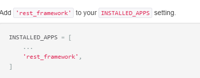

     ]
   - then add the app name in installed apps
   - [goto the views and
   - [

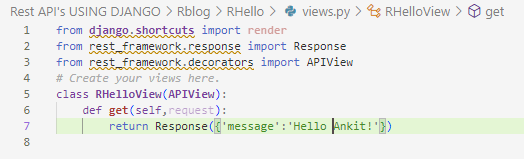

     ]
   - []
   - [

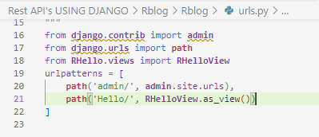

     ]

# **Creating model in the admin**

- - [

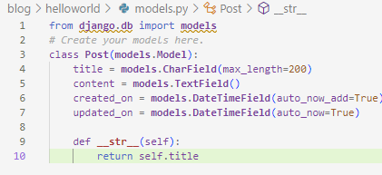

    ]
  - []
  - []
  - []
  - [

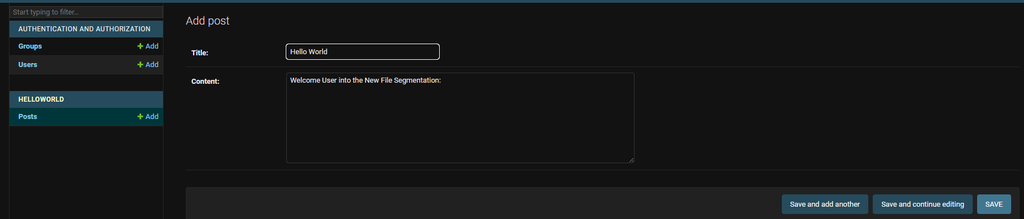

    ]
  - []
  - [

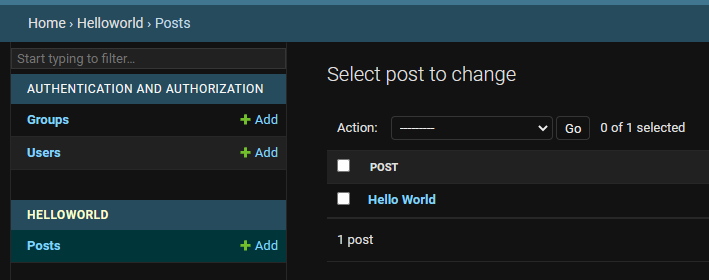

    ]

# **Posting API's**

- [

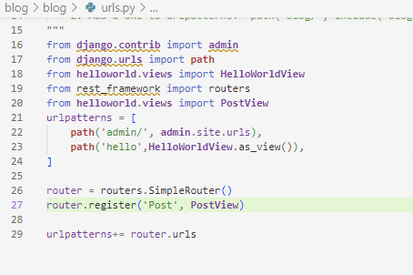

  ]
- []
- [

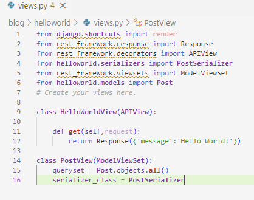

  ]
- []
- [

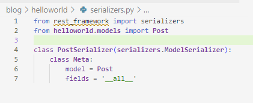

  ]
- [to check the data ]
- [

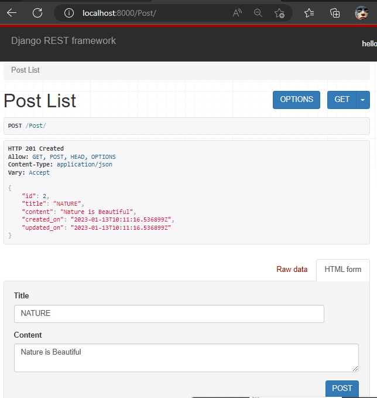

  ]
- [for deleting the data ]
- [

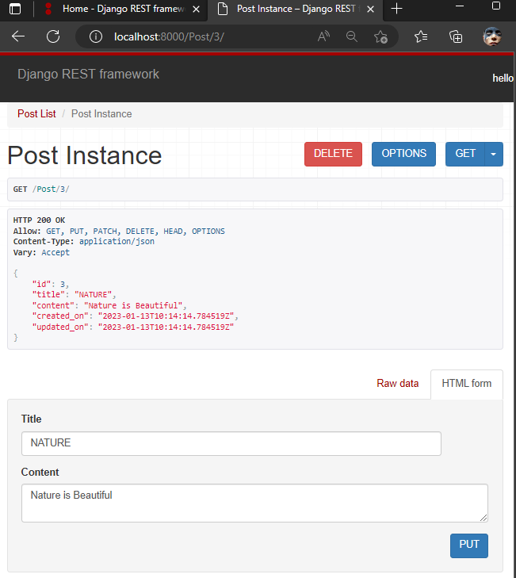

  ]
- [**How to post API the Django rest_framework** ]

# **Segregation into pages**

Whenever you wanna load so much data in a single page your performance decreaces. You can segregate into the seperate pages, so that segregation is known as pagination

- [

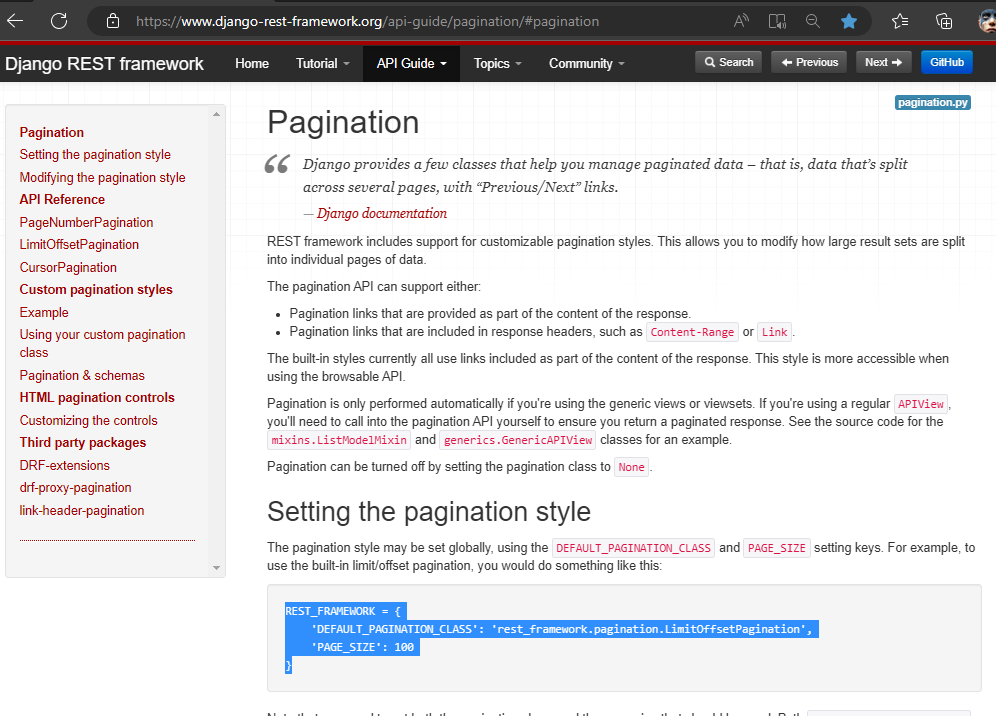

  ]
- [

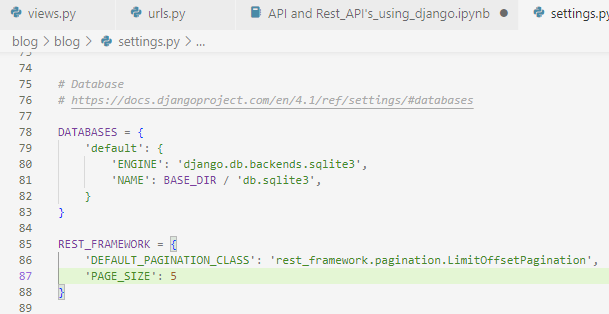

  ]
- [

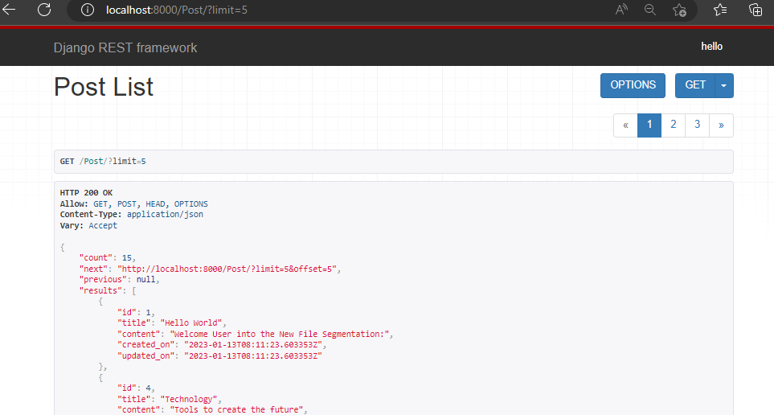

  ]

# **Setting an Authentication**

- [

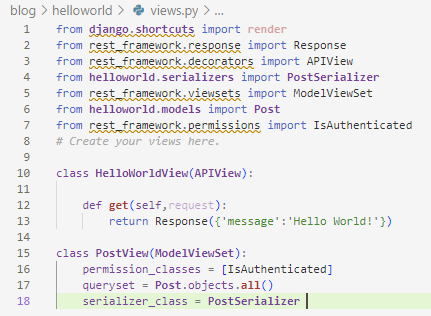

  ]
- [Authentication process and their codes]
- [

[figure not shown]

  ]
- [to set the path in the ulrspattern]
- [

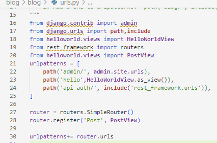

  ]

# **Adding username to the post**

- [

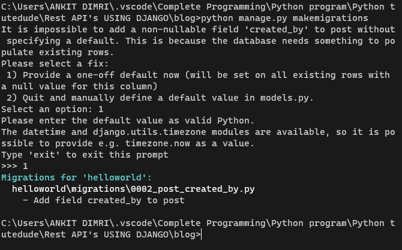

  ]
- [MAKEMIGRATIONS]
- [

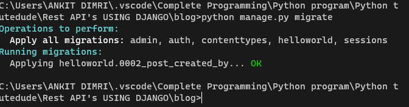

  ]
- []
- [

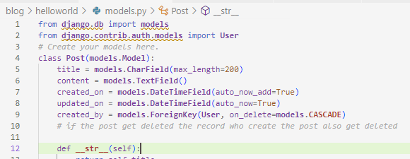

  ]
- []
- [

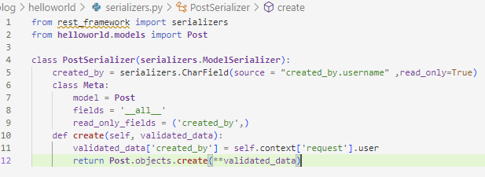

  ]

**If you want to delete some post since the post created by the user i want to change this permission. that is provided to the admin/hello. i want only the user who created the post who deleted.**

# **Adding Permisssion**

we can only read that file which one is created by other user. but cannot delete that file from admin database

- [

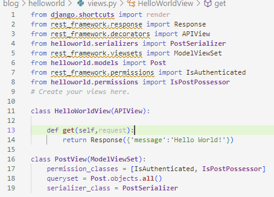

  ]
- []
- [

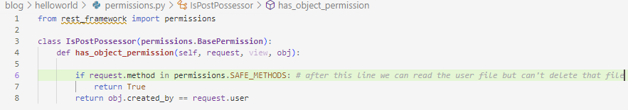

  ]
- []
- [

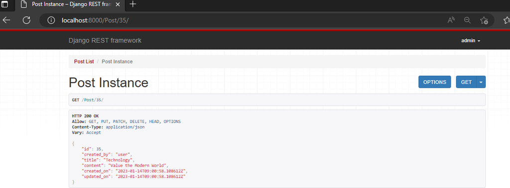

  ]

[figure not shown]

# **Filtering Based on usernames**

now set the basic filter

- [

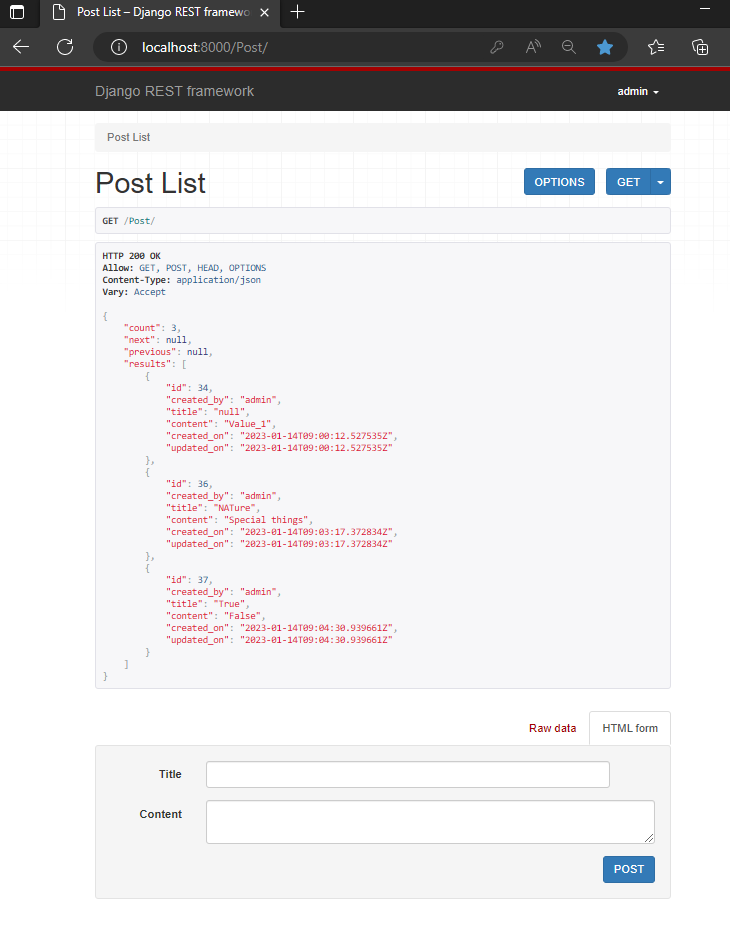

  ]
- []
- [

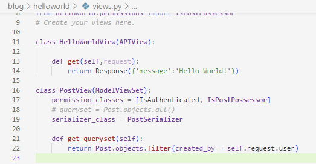

  ]
- []
- [

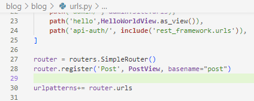

  ]

so now we can see their is no user files in the admin user

- whatever the user you log in to you will get that post

_________________________-

# **Search Filter**

- now we import the filter
  - [

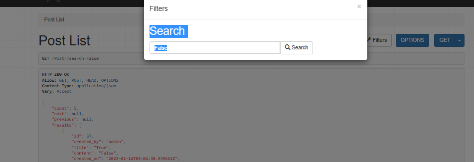

    ]
- []
  - [

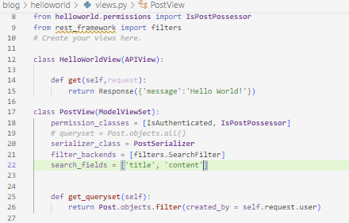

    ]
- []